# The Tech Industy in Los Angeles

2018 Nov 17

The tech industry provices high paying jobs. Major contributor to the economy. For example, in 2017, while the media wage for all occupations was $37,700 in the U.S., it was $84,600 for the computer occupations, second only to $102,600 of the management occupations. (Mr. William Yu)

# Gender Equality

[figure not shown]

A 2015 [survey](https://www.aauw.org/research/solving-the-equation/) showed that only 26% of data jobs are held by women [1]. However, lack of feminine perspective creates blind spots such as the [#googleWalkout](https://www.theverge.com/2018/11/2/18057716/google-walkout-20-thousand-employees-ceo-sundar-pichai-meeting) [2] and is bad business - says Forbes [3]. In Fig. 1 (above), we use superhero-themes #batman #wonderwoman to visualize the heavy topic of #gender_equality in #datascience. See a bar chart for a more accurate breakdown [4]. Source: survey question Q1 - What is your gender? Sample size = 23,859 respondents

# 1 Cohorts

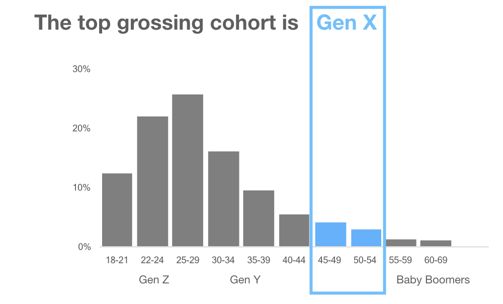

What can we learn from our data scientist uncle? Fig. 2 is user distribution by age. We use a two-color scheme [18] to highlight which age-group won most competitions per user*. However, just a few too many age bins can overwhelm any reader. A way to declutter and structure the bins into usable knowledge is to reduce their numbers and group them in a familiar, relatable form. One way is to group the bins by generations. In this case, we used the [Generations in the workforce](https://en.wikipedia.org/wiki/Generations_in_the_workforce) (the gen X, Y, Z and the Boomers [5]) and we are interested to see which group is the most productive in terms of competitions and cash prizes per user. Because everyone belongs to a generation this chart can become very personable. What can we learn from the wisdom that each generation offers?

Generation year brakets and work-ethic attribute

- The Baby Boomers, born 1946 - 1964 “often branded workaholics” [6]
- Gen X, born 1967 - 1977 “this generation works to live and carry with them a level of cynicism” [7]
- Gen Y, “Millennials” born 1980 - 2000 “considered the most educated and self-aware generation in employment” [8]
- Gen Z, born 2000 -

*Source: Own estimate, [xSurvey](https://uaeu.typeform.com/to/aaxMAz). Source - Q2 : What is your age (# years)?

# 2 Inclusion

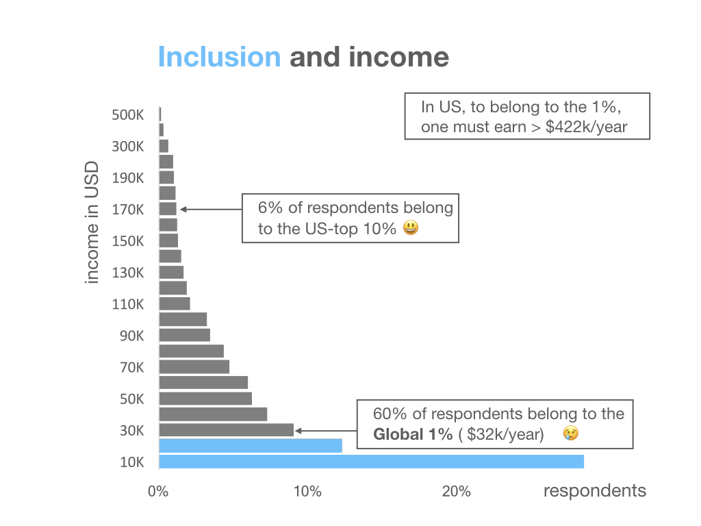

Fig. 3 tells a #digitaldivide story. How inclusive are we as a community? Should we pat ourselves on our backs? Again, to create knowledge we need to relate the data to the reader in ways they can connect it to other knowledge they have. Here, one way is to use the income percentiles (see #onepercent). In US, to belong to the 1% elite, one needs to earn more than $422k per year [10]. About 23 respondents declared that they do. In addition, about 6% declared they belong to the 10% percentile, a very inclusive number because 6% is similar to 10%. The 10% percentile income is about $166k in US [11], so if the sample reflects the distribution found in society it means it is at least somehow inclusive. We add a smiley emoji to reassure the reader that yes, this is good.

However, those numbers are for US household incomes. When we look globally, the 1% percentile thereshold is $32k per year. This puts 60% of the respondents in the top 1%. 60% is very different from 1% so globally this datapoint does not support inclusiveness because it does not reflect the global distribution. #Ahamoment. One way to create such moments in the story is to A/Bify the story by switching between two points of view. Source - Q9 : What is your current yearly compensation (approximate $USD)?

# 3 ML Champions

[figure not shown]

Fig. 4. This chart is an example of less is more. Many times, displaying detailed percentages of usage adds little to the story. In this case Sci-Kit has a 48% share, TF has a 16%, followed by Keras 14%. However, anthropomorphizing the ranking with a podium conveys a memorable affordance: the glory the winner deserves for the great utility this library provided to the community. The podium-template is from a [#sketchthinking](http://www.amazon.com/Sketch-Thinking-design-ebook/dp/B014BMONTG) book [12]. Source - Q20 : Of the choices that you selected in the previous question, which ML library have you used the most?

# 4 Viz Leaders

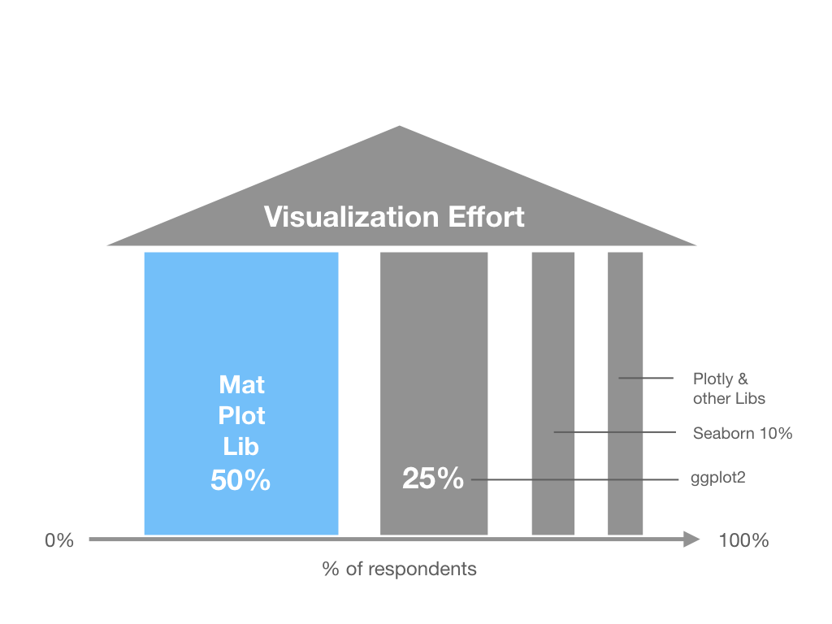

Fig. 5. This is a combination of a famous chart template called *Marimekko*, with a symbolic chart called *House of Shiva* [13-14]. Symbolism: The columns, support the visualization efforts of the community. The width of the “columns” expresses how much work/load each column supports. Grey columns on the right represent other less mainstream libs such as: D3, Shiny, bokeh, Leaflet, Lattice.

Source - Q22 : …which specific data visualization library or tool have you used the most?

# 5 New Users (BRICS)

[figure not shown]

Fig. 6. Where do new data scientists users come from? 1145 new data sceintist where added in 2018 from more than 100 countries. A typical mistake here is count grouping by country. There are too many countries for a human to make sense of it! It makes much more sense to group them in economic mega regions: US, Europe, BRICS and the rest of World. (The term “BRIC” was coined in 2001 by then-chairman of Goldman Sachs Asset Management,Jim O’Neill [16].) When we do that we see that not only is BRICS the top contributor to growth in data scientists with 42% of total growth for 2018, but it was also the fastest growing among the big three. In 2018, Europe added 302 users that define themselves as data scientist, US: 131, the rest of the world : 231, and BRICS: 481. Regarding growth rates, by 2020 BRICS will outnumber Europe and US combined.

Data source: we [forked](https://www.kaggle.com/harriken/kaggle-journey-2017-2018?scriptVersionId=7123143) and modified a snippet the excellent code from [15] and took the top 20 countries whose respondents identified as “data scientist” [17]. EU-6 means the top 6 European countries.